# Análise de Criminalidade no Estado de São Paulo (2016-2025)

github.com/RFaleiro 2026-03-13

## 1. Proposta

Este relatório fornece uma análise extensa dos dados de segurança pública do Estado de São Paulo de 2016 até o início de 2025. Ao agregar mais de 80 métricas distintas de criminalidade, buscamos descobrir tendências macro, identificar as anomalias de crescimento mais rápido pós-pandemia e destacar atividades criminosas correlacionadas.

### 1.1 Base de dados

A extração dos dados é realizada de forma automatizada (via *web scraping*) diretamente do portal da Secretaria de Segurança Pública do Estado de São Paulo (SSP-SP).

Para coletar o histórico completo ano a ano, o nosso script constrói dinamicamente a URL de origem das tabelas estatísticas. O endereço base segue um padrão estruturado onde o **ano** e o **trimestre** são alterados programaticamente na URL:

`https://www.ssp.sp.gov.br/assets/estatistica/trimestral/arquivos/{ano}-{trimestre}.htm`

**Como funciona a montagem dinâmica da URL:**

- **`{ano}`**: Varia em um loop de 2016 até o ano atual (2025).
- **`{trimestre}`**: Varia de `01` a `04` (sempre com dois dígitos), representando cada trimestre do respectivo ano.

Desta forma, o *crawler* substitui essas variáveis iterativamente (por exemplo, acessando a página de dados de `.../2023-01.htm`, seguida por `.../2023-02.htm`, etc.) e faz o download de todos os relatórios, consolidando todo o histórico em um único grande arquivo para a nossa análise.

Os relatórios em formato PDF gerados durante a coleta dos dados brutos podem ser acessados diretamente através deste link para a pasta `data/raw/pdf_ssp_reports/`.

## 2. Tendências Gerais

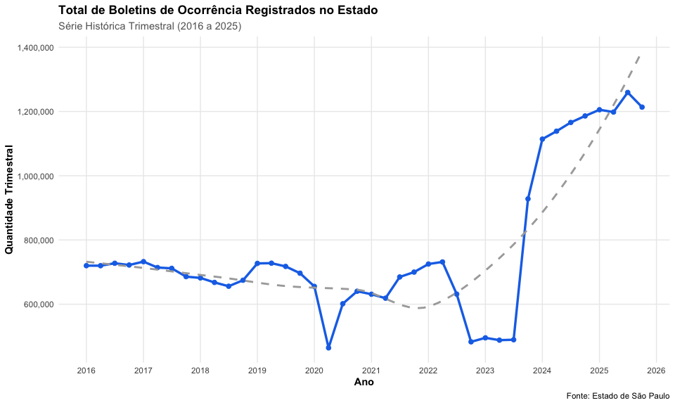

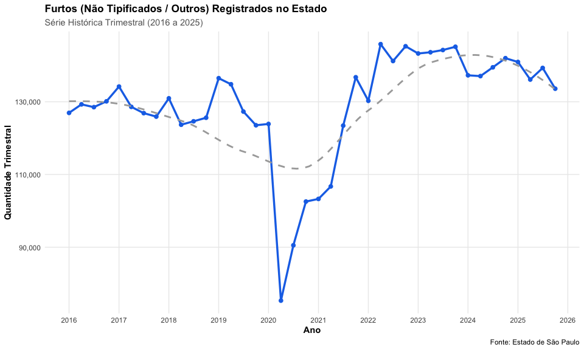

A análise exploratória das **Tendências Gerais** da segurança pública em São Paulo nos revela dois panoramas bastante claros na série histórica:

1. **A Escalada Alarmante dos Boletins Totais de Ocorrência:** Ao observar a linha geral do Estado, o período pré-pandemia (2016 a 2019) mantinha um registro firme na ordem de **705.162 ocorrências por trimestre**. Após um natural e trágico engessamento do número em 2020 e 2021 pela falta de mobilidade no isolamento dos lockdowns (o grande *vale* no gráfico), houve um rebote dramático: no período pós-2022 o número de boletins trimestrais bateu sucessivos recordes, se perpetuando numa média absurda de **990.152 registros por trimestre**. O cume desse volume denota um incremento estrondoso de **+40,4%** a mais de ocorrências despachadas rotineiramente perante a média histórica pré-crise.
2. **O Crescimento Brando e Descorrelacionado dos Furtos:** Por vias analíticas opostas, ao insulormos os chamados casos de **Furto - Outros** (aqueles de baixa resolução e não enquadrados puramente em perfis como veículos pesados), percebemos que o seu padrão sofreu um deslocamento bem inferior. A base de dados revela que, antes de 2020 a média era de *128.597* casos reportados nestas infrações e, mesmo após todo o boom de 2023 pra frente, ele subiu de forma contida para a base de *140.173 casos*. É uma alta de apenas **+9,0%**.

Isso nos leva a uma conclusão importantíssima do ponto de vista investigativo: **como os furtos simples não cresceram na mesma proporção desvairada do todo, conclui-se que o avanço crítico de mais de 40% empurrado no volume macro da Secretaria da Segurança Pública de SP foi insuflado pesadamente por crimes mais diversificados, ou até ocorrências atípicas e violentas que fugiram ao controle ao longo dessa mesma linha de tempo.**

### 2.1 Crimes que mais cresceram

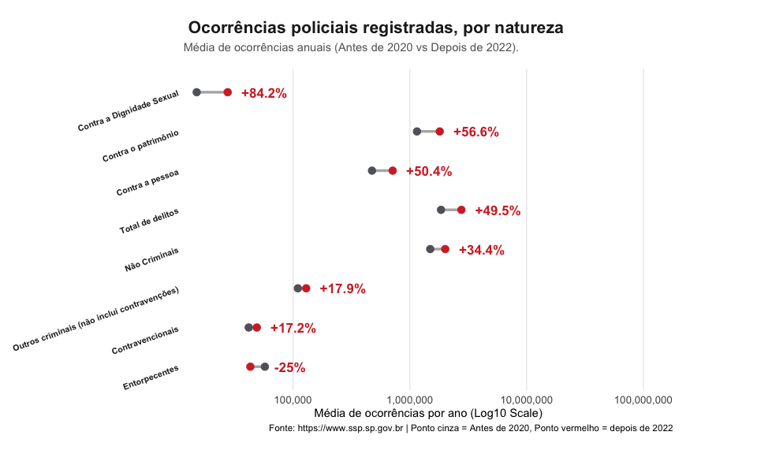

| Métrica | Média de ocorrências/Ano (Pré-2020) | Média de ocorrências/Ano (Pós-2022) | Crescimento |
| --- | --- | --- | --- |
| Contra a Dignidade Sexual | 14,970 | 27,570 | 84.2% |
| Contra o patrimônio | 1,152,063 | 1,803,896 | 56.6% |
| Contra a pessoa | 474,304 | 713,229 | 50.4% |
| Total de delitos | 1,850,511 | 2,766,427 | 49.5% |
| Não Criminais | 1,495,679 | 2,010,436 | 34.4% |
| Outros criminais (não inclui contravenções) | 109,970 | 129,669 | 17.9% |
| Contravencionais | 41,768 | 48,962 | 17.2% |
| Entorpecentes | 57,436 | 43,101 | -25.0% |

A Explosão da Violência Contra a Dignidade Sexual e Patrimônio

O primeiro gráfico de halteres revelando os perfis agregados **por natureza criminal** explica visceralmente para onde a carga violenta escorreu após todo o desmembramento promovido pelo fechamento social. O grande propulsor que mais alavancou os números macabros contra a sociedade civil paulista foi aterradoramente associado aos **Crimes Contra a Dignidade Sexual** (que inflaram impressionantes **+84,2%** em volume absoluto de ocorrências em todo fluxo pós-pandêmico comparado ao histórico até 2019).

Na sequência do horror, os gigantes demográficos do relatório, como **Crimes Contra o Patrimônio** (aumentando **+56,6%** e puxando uma brutal volumetria real para casa dos milhões) e os **Crimes Contra a Pessoa** (pesando **+50,4%** no Estado) atestam uma perda agressiva de freios em todos os campos da convivência urbana e física, inflando desproporcionalmente o Total de Delitos que comentamos alhures.

Nota-se também que **Entorpecentes** foi literalmente a única frente criminal documentada que cedeu drasticamente (uma queda linear de **-25%**). Isso sugere possivelmente um gargalo operacional, subnotificação investigativa, mudança pesada de comando ou uma forte alteração das estratégias e focos de operação na atuação flagrante nas pontas nos últimos anos.

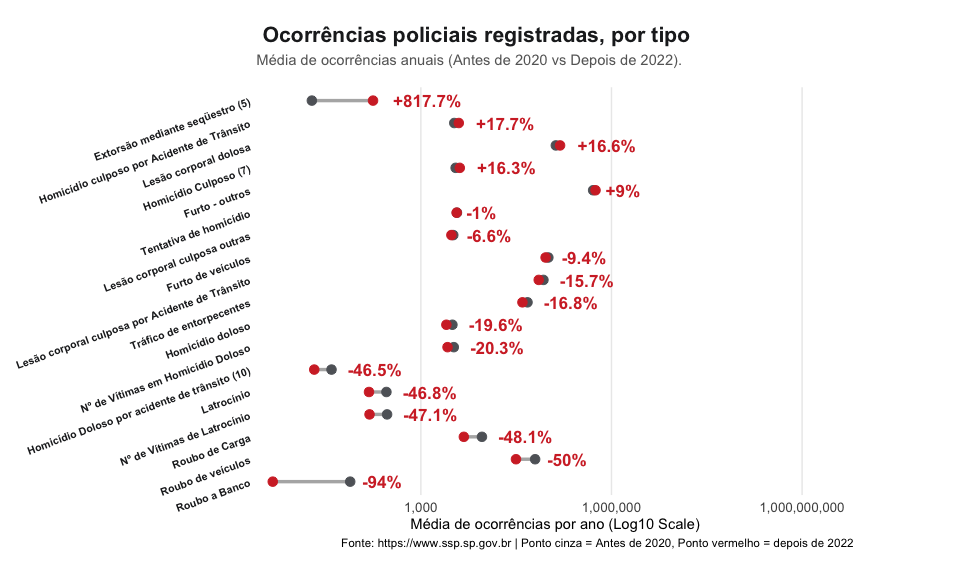

| Métrica | Média de boletins de ocorrência/Ano (Pré-2020) | Média de boletins de ocorrência/Ano (Pós-2022) | Crescimento |
| --- | --- | --- | --- |
| Extorsão mediante seqüestro (5) | 19 | 177 | 817.7% |
| Homicídio culposo por Acidente de Trânsito | 3,356 | 3,951 | 17.7% |
| Lesão corporal dolosa | 133,105 | 155,160 | 16.6% |
| Homicídio Culposo (7) | 3,526 | 4,099 | 16.3% |
| Furto - outros | 514,388 | 560,691 | 9.0% |
| Tentativa de homicídio | 3,694 | 3,657 | -1.0% |
| Lesão corporal culposa outras | 3,236 | 3,022 | -6.6% |
| Furto de veículos | 101,440 | 91,863 | -9.4% |
| Lesão corporal culposa por Acidente de Trânsito | 84,933 | 71,603 | -15.7% |
| Tráfico de entorpecentes | 47,675 | 39,681 | -16.8% |
| Homicídio doloso | 3,136 | 2,520 | -19.6% |
| Nº de Vítimas em Homicídio Doloso | 3,298 | 2,628 | -20.3% |
| Homicídio Doloso por acidente de trânsito (10) | 39 | 21 | -46.5% |
| Latrocínio | 287 | 153 | -46.8% |
| Nº de Vítimas de Latrocínio | 294 | 156 | -47.1% |
| Roubo de Carga | 9,148 | 4,748 | -48.1% |
| Roubo de veículos | 62,850 | 31,397 | -50.0% |
| Roubo a Banco | 77 | 5 | -94.0% |

**A Migração do Crime: Extorsões Explodem, Roubos de Alto Padrão Desabam:** Ao destrincharmos rigorosamente os dados dentro das tipificações criminais do segundo gráfico, uma radiografia espantosa e muito singular da sociedade paulista se desenha. O crime organizado comum operou uma pivotagem brutal no Estado de São Paulo abandonando os crimes tradicionalmente caracterizados como *‘defesa do patrimônio das elites e corporações’* e escorrendo para a impunidade do ambiente digital e da extorsão direta na rua.

**O Que Mais Desabou:** Houve um colapso gigantesco e estatisticamente perfeito nas ocorrências que demandam confronto direto contra capital fortificado e corporativo. A base revela que **Roubo a Banco (derretimento de -94%)**, **Roubo de Veículos (-50%)**, **Roubo de Carga (-48,1%)** e até o trágico **Latrocínio (-46,8%)** caíram praticamente pela metade em comparação com a rotina paulista antes de 2020. O governo obteve aparente controle pleno nas vitrines ostensivas de segurança privada/pública nos redutos de grande patrimônio.

**O Que Mais Explodiu (O Novo Custo Brasil):** Toda a criminalidade contida nos muros corporativos buscou uma assustadora compensação no cidadão civil comum. A tipificação que sofreu o aumento mais alucinante e bizarro de toda a história da SSP-SP foi a **Extorsão Mediante Seqüestro (o famigerado ‘Golpe do PIX’ / Sequestro Relâmpago)** que subiu absurdos **+817,7%** (saltando de 19 casos/ano para estratosféricos 177 casos anuais mapeados em média). Essa transição do criminoso saindo da porta do banco para invadir a transação bancária no celular do refém na rua se provou um pesadelo incontornável.

Paralelamente, o convívio social urbano demonstrou esgarçamento fatal. Os **Homicídios por Acidente de Trânsito** cresceram significativamente (**+17,7%**, perfazendo em média quase 4.000 mortos registrados sob esse flagelo anualmente), e a pura **Lesão Corporal Dolosa** (agressão com intenção de ferir e brigas generalizadas da rua a lares civis) marcou uma alta de **+16,6%**, superando um patamar horripilante de mais de 155.000 vítimas catalogadas por ano frente ao período antes do isolamento.

### 2.2 Tendência para crimes contra a Pessoa

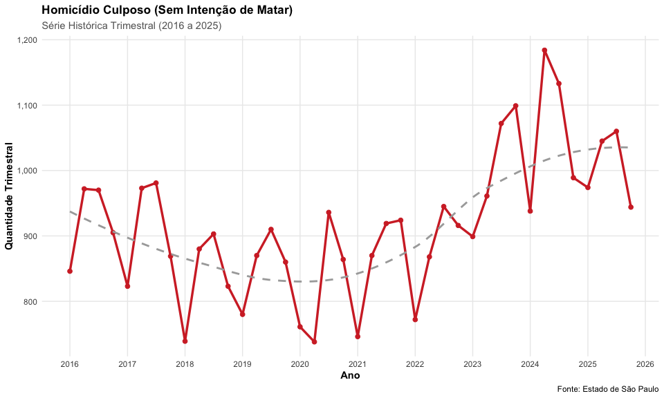

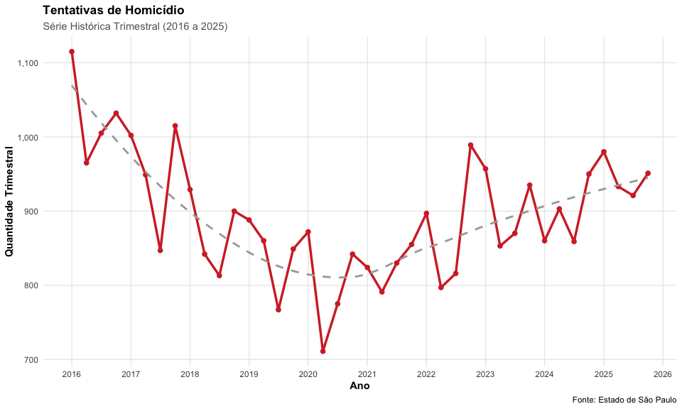

A análise específica dos **Crimes contra a Pessoa**, abordando mortes culposas e atentas à vida que não se consumaram, traz um contraponto importante sobre qual perfil de violência está crescendo verdadeiramente no Estado de São Paulo:

1. **Aumento Consistente dos Homicídios Culposos:** Observamos uma tendência consolidada de alta nos homicídios culposos (onde não há intenção primária de matar, estando frequentemente associados a fatalidades sistêmicas, violência no trânsito ou negligência imprudente). A série apresentava uma média contida em cerca de **882 casos** por trimestre antes da pandemia; porém, a curva cresceu de forma contínua a ponto de cruzar, repetidas vezes, a barreira de mais de **1.000 mortes/trimestre** a partir de 2023. Isso compõe um aumento sistemático e não-ignível de **+16,3%**.
2. **Estabilidade Absoluta nas Tentativas de Homicídio:** Em contrapartida nítida, as *Tentativas de Homicídio* (crimes violentos, agressões diretas com dolo de matar, mas interceptadas) não pioraram estruturalmente. A sua média pré-crise orbitava na casa de 924 registros trimestrais, oscilando para exatos **914 casos/trimestre** no período recente pós-2022. Essa é uma variação achatada de essencialmente **-1,0%** (estabilidade perfeita).

A união destes dois cenários endossa a lógica discutida na tendência geral: ao cruzar a não-piora da intenção ativa de matar de um lado e o salto formidável em vítimas letais de homicídios culposos do outro, concluímos que a violência clássica e premeditada das ruas paulistas não avançou massivamente — o perigo e as fatalidades estruturais cresceram através de vias mais imprudentes/acidentais dentro da sociedade ou tráfego civil.

### 2.3 Tendência para crimes contra o patrimônio

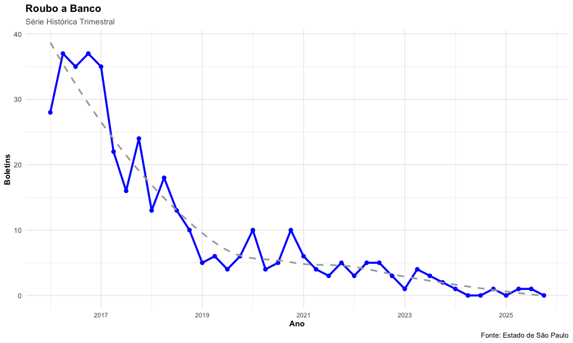

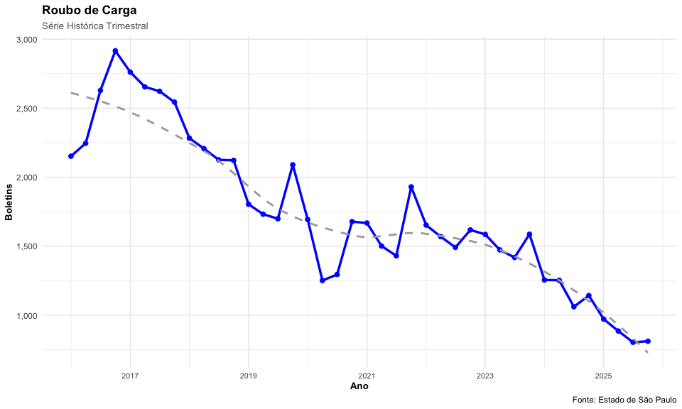

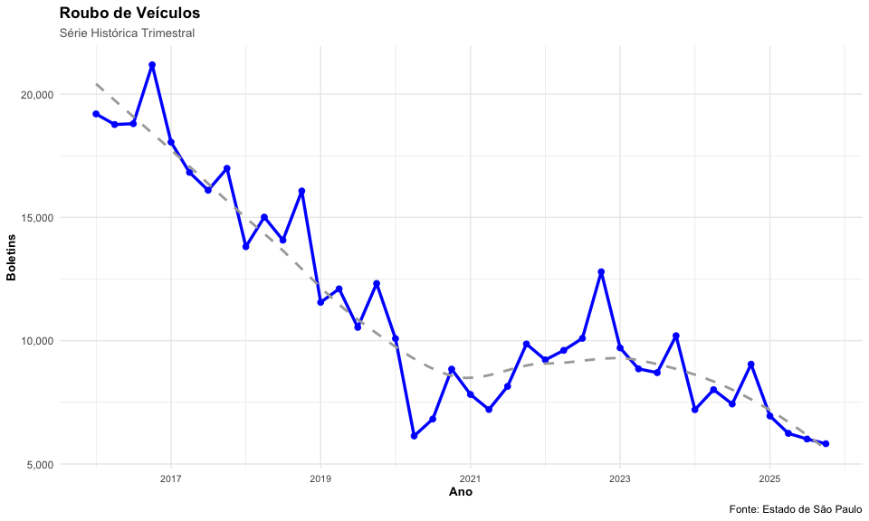

Quando passamos a lupa nas estatísticas sobre aquilo que classicamente se estrutura como a **“Defesa do Patrimônio”**, cruzamos com a única frente de segurança que apresentou um sucesso operacional na última década no Estado de São Paulo. Se as ocorrências totais estaduais escalaram mais de +40%, os crimes vitrine não seguiram a mesma sorte:

## 3. Crimes Graves - Estupro

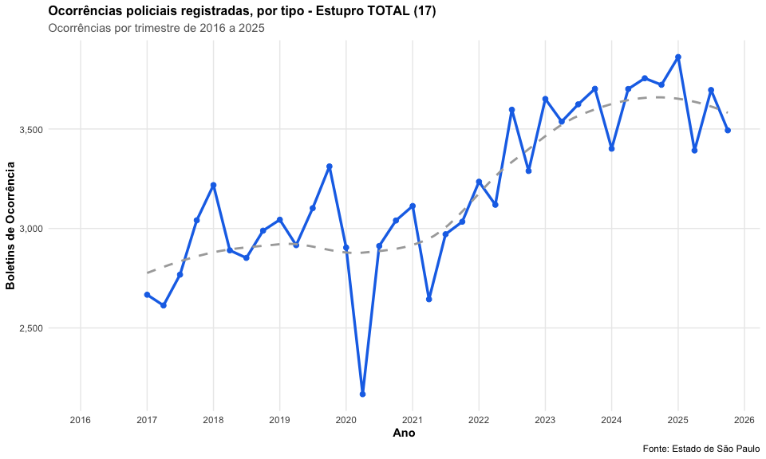

### 3.1 Taxa de crescimento de estupros

[figure not shown]

## 4. O Custo Humano do Confronto: Letalidade e Atuação Policial

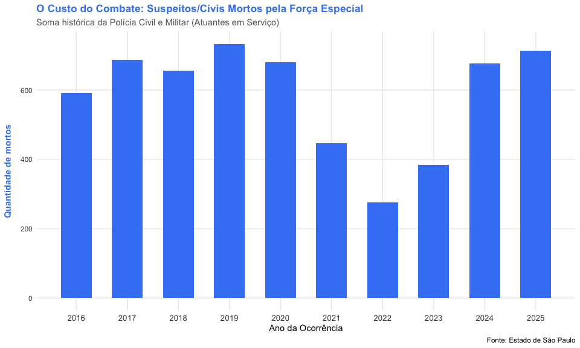

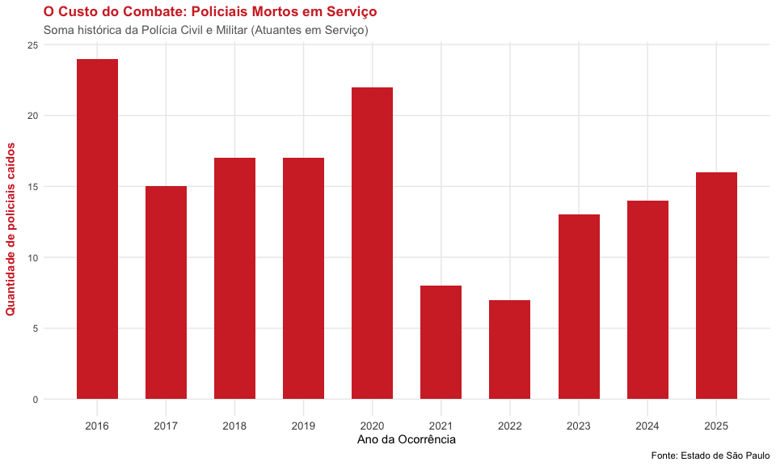

Este tópico analisa o cenário de letalidade decorrente da intervenção estatal, onde o confronto direto entre forças de segurança e civis revela o lado mais trágico da insegurança pública. Longe de serem apenas números, esses dados representam uma guerra urbana que exige esforços contínuos de controle e redução, uma vez que o desfecho letal sinaliza uma falha no processo de pacificação onde todos os lados sofrem perdas irreparáveis.

A análise dos indicadores aponta para uma dinâmica de resistência e vitimização que, embora em patamares menores que no passado, ainda demanda atenção crítica:

### 4.1 Vidas Perdidas em Intervenções Policiais

Os dados consolidados das polícias Civil e Militar indicam que o número de civis mortos em confrontos durante o serviço apresentou uma redução.

- **Média Pré-2020:** ~660 mortes anuais.
- **Média Pós-2022:** ~590 mortes anuais.
- **Variação:** `-11%`

> **Nota Crítica:** Embora o recuo estatístico seja um passo em direção ao controle da força, o volume de óbitos ainda evidencia a alta voltagem dos conflitos nas periferias e centros urbanos.

### 4.2 A Vitimização dos Agentes de Segurança

A letalidade também atinge aqueles que operam o braço armado do Estado. A perda de vidas de oficiais no cumprimento do dever registrou o seguinte comportamento:

- **Média Pré-2020:** 18 agentes por ano.
- **Média Pós-2022:** 14 agentes por ano.
- **Variação:** `-20%`

A queda na perda de vidas de policiais é um indicador positivo de preservação da integridade dos agentes, mas cada óbito representa uma ruptura no sistema de segurança e um custo humano inaceitável para as famílias e para a instituição.

### Conclusão do Cenário

Os dados sugerem que o agravamento da insegurança percebido pelo cidadão no dia a dia (como nos crimes digitais e patrimoniais) não tem sido acompanhado, proporcionalmente, por uma escalada na guerra letal entre Estado e crime organizado.

No entanto, a manutenção de centenas de mortes anuais reforça a urgência de políticas de segurança baseadas em **inteligência e desescalada**, visando reduzir ao máximo o confronto armado e preservar a vida de todos os envolvidos.